# Model Planning and Building

Aaron Nicanor’s Data Science Portfolio Project

### Introduction

In this part of the project, I’d like to see what are the possible predictors of a games sales. This is important information since it’ll give pointers towards developers on what they could do to sell to a larger audience, and it’ll provide insight on what made a game sell well.

To supplement my data, I’ve included a web scrape from the site vgchartz. This site provides information about console sales, and will act as an addition predictor.

### Libraries and Resources

First, I’ll have to load in the libraries I’ll be using in addition to what I’ve done in the previous part of this project.

```r
suppressMessages(library("tidyverse"))
suppressMessages(library("knitr"))
suppressMessages(library("caret"))
suppressMessages(library("rvest"))
suppressMessages(library("stringr"))
purl("Discovery_And_DataPrep.Rmd", output = "part1.r")
```

```
##
##
## processing file: Discovery_And_DataPrep.Rmd
```

[output not shown]

```
## output file: part1.r
```

```
## [1] "part1.r"
```

```r
source("part1.r")
```

[output not shown]

[output cut: 65 more lines]

```
## # A tibble: 10 x 10
##    Title Publisher Developer `Year of Releas~ Platform Rating Genre
##    <fct> <fct>     <fct>     <fct>            <fct>    <fct>  <fct>
##  1 Wii ~ Nintendo  Nintendo  2006             Wii      E      Spor~
##  2 Mari~ Nintendo  Nintendo  2008             Wii      E      Raci~
##  3 Wii ~ Nintendo  Nintendo  2009             Wii      E      Spor~
##  4 New ~ Nintendo  Nintendo  2006             DS       E      Plat~
##  5 Wii ~ Nintendo  Nintendo  2006             Wii      E      Misc
##  6 New ~ Nintendo  Nintendo  2009             Wii      E      Plat~
##  7 Mari~ Nintendo  Nintendo  2005             DS       E      Raci~
##  8 Wii ~ Nintendo  Nintendo  2007             Wii      E      Spor~
##  9 Kine~ Microsof~ Good Sci~ 2010             X360     E      Misc
## 10 Wii ~ Nintendo  Nintendo  2009             Wii      E      Spor~
## # ... with 3 more variables: `Global Sales` <dbl>, `Critic Score` <fct>,
## #   `Critic Count` <int>
```

I’ll also need to load in my supplementary data.

```r
#Yoink the URL
URL_ConsoleSales <- "http://www.vgchartz.com/analysis/platform_totals/Hardware/Global/"
html <- read_html(URL_ConsoleSales)

#Pinning down the rows that I'll be scrapping from
rows <- html %>% html_nodes(xpath = '//*[@id="myTable"]/tbody/tr')

#Grabbing all observations I need
Platform <- rows %>%
  html_nodes(xpath = '//*[@id="myTable"]/tbody/tr/td[2]') %>%
  html_text()
NA_Sales <- rows %>%
  html_nodes(xpath = '//*[@id="myTable"]/tbody/tr/td[3]') %>%
  html_text()
EU_Sales <- rows %>%
  html_nodes(xpath = '//*[@id="myTable"]/tbody/tr/td[4]') %>%
  html_text()
JP_Sales <- rows %>%
  html_nodes(xpath = '//*[@id="myTable"]/tbody/tr/td[5]') %>%
  html_text()
Other_Sales <- rows %>%
  html_nodes(xpath = '//*[@id="myTable"]/tbody/tr/td[6]') %>%
  html_text()
Global_Sales <- rows %>%
  html_nodes(xpath = '//*[@id="myTable"]/tbody/tr/td[7]') %>%
  html_text()

#Create a tibble of my newly aquired data
ConsoleSalesData <- tibble(Platform=Platform,
                           'NA Console Sales'=NA_Sales,
                           'EU Console Sales'=EU_Sales,
                           'JP Console Sales'=JP_Sales,
                           'Other Console Sales'=Other_Sales,
                           'Global Console Sales'=Global_Sales)
```

### Data Organization

I’ll need to reorganize my supplementary data so that it’s tidy and clean

```r
#Here, I convert each column into its appropriate type
ConsoleSalesData[2] <- ConsoleSalesData$`NA Console Sales` %>% as.numeric()
ConsoleSalesData[3] <- ConsoleSalesData$`EU Console Sales` %>% as.numeric()
ConsoleSalesData[4] <- ConsoleSalesData$`JP Console Sales` %>% as.numeric()
ConsoleSalesData[5] <- ConsoleSalesData$`Other Console Sales` %>% as.numeric()
ConsoleSalesData[6] <- ConsoleSalesData$`Global Console Sales` %>% as.numeric()

#This absolute monster of a code chunk is just me converting the names of each console into something that matches the naming convention used in part 1 of this project.
ConsoleSalesData$Platform[ConsoleSalesData$Platform=='3DO Interactive Multiplayer (3DO)'] <- '3DO'
ConsoleSalesData$Platform[ConsoleSalesData$Platform=='Atari 2600 (2600)'] <- '2600'
ConsoleSalesData$Platform[ConsoleSalesData$Platform=='Atari 7800 (7800)'] <- '7800'
ConsoleSalesData$Platform[ConsoleSalesData$Platform=='Dreamcast (DC)'] <- 'DC'
ConsoleSalesData$Platform[ConsoleSalesData$Platform=='Game Boy (GB)'] <- 'GB'
ConsoleSalesData$Platform[ConsoleSalesData$Platform=='Game Boy Advance (GBA)'] <- 'GBA'
ConsoleSalesData$Platform[ConsoleSalesData$Platform=='GameCube (GC)'] <- 'GC'
ConsoleSalesData$Platform[ConsoleSalesData$Platform=='GameGear (GG)'] <- 'GG'
ConsoleSalesData$Platform[ConsoleSalesData$Platform=='iOS (iOS)'] <- 'iOS'
ConsoleSalesData$Platform[ConsoleSalesData$Platform=='Microsoft Windows (PC)'] <- 'PC'
ConsoleSalesData$Platform[ConsoleSalesData$Platform=='Neo Geo (NG)'] <- 'NG'
ConsoleSalesData$Platform[ConsoleSalesData$Platform=='Nintendo 3DS (3DS)'] <- '3DS'
ConsoleSalesData$Platform[ConsoleSalesData$Platform=='Nintendo 64 (N64)'] <- 'N64'
ConsoleSalesData$Platform[ConsoleSalesData$Platform=='Nintendo DS (DS)'] <- 'DS'
ConsoleSalesData$Platform[ConsoleSalesData$Platform=='Nintendo Entertainment System (NES)'] <- 'NES'
ConsoleSalesData$Platform[ConsoleSalesData$Platform=='Nintendo Switch (NS)'] <- 'NS'
ConsoleSalesData$Platform[ConsoleSalesData$Platform=='PC-FX (PCFX)'] <- 'PCFX'
ConsoleSalesData$Platform[ConsoleSalesData$Platform=='PlayStation (PS)'] <- 'PS'
ConsoleSalesData$Platform[ConsoleSalesData$Platform=='PlayStation 2 (PS2)'] <- 'PS2'
ConsoleSalesData$Platform[ConsoleSalesData$Platform=='PlayStation 3 (PS3)'] <- 'PS3'
ConsoleSalesData$Platform[ConsoleSalesData$Platform=='PlayStation 4 (PS4)'] <- 'PS4'
ConsoleSalesData$Platform[ConsoleSalesData$Platform=='PlayStation Portable (PSP)'] <- 'PSP'
ConsoleSalesData$Platform[ConsoleSalesData$Platform=='PlayStation Vita (PSV)'] <- 'PSV'
ConsoleSalesData$Platform[ConsoleSalesData$Platform=='Sega CD (SCD)'] <- 'SCD'
ConsoleSalesData$Platform[ConsoleSalesData$Platform=='Sega Genesis (GEN)'] <- 'GEN'
ConsoleSalesData$Platform[ConsoleSalesData$Platform=='Sega Saturn (SAT)'] <- 'SAT'
ConsoleSalesData$Platform[ConsoleSalesData$Platform=='Super Nintendo Entertainment System (SNES)'] <- 'SNES'
ConsoleSalesData$Platform[ConsoleSalesData$Platform=='TurboGrafx-16 (TG16)'] <- 'TG16'
ConsoleSalesData$Platform[ConsoleSalesData$Platform=='Wii (Wii)'] <- 'Wii'
ConsoleSalesData$Platform[ConsoleSalesData$Platform=='Wii U (WiiU)'] <- 'WiiU'
ConsoleSalesData$Platform[ConsoleSalesData$Platform=='WonderSwan (WS)'] <- 'WS'
ConsoleSalesData$Platform[ConsoleSalesData$Platform=='Xbox (XB)'] <- 'XB'
ConsoleSalesData$Platform[ConsoleSalesData$Platform=='Xbox 360 (X360)'] <- 'X360'
ConsoleSalesData$Platform[ConsoleSalesData$Platform=='Xbox One (XOne)'] <- 'XOne'

#I convert the Platform column into a tibble
ConsoleSalesData$Platform <- as.factor(ConsoleSalesData$Platform)

#I removed these rows from my data since the data they provided was NULL.
ConsoleSalesData <- ConsoleSalesData[-c(28:34),]

#With all that done, I can show off the final table
ConsoleSalesData
```

| Platform | NA Console Sales | EU Console Sales | JP Console Sales | Other Console Sales | Global Console Sales |
| --- | --- | --- | --- | --- | --- |
| PS2 | 53.65 | 55.28 | 23.18 | 25.57 | 157.68 |
| DS | 57.39 | 52.07 | 33.01 | 12.43 | 154.90 |
| GB | 43.18 | 40.05 | 32.47 | 2.99 | 118.69 |
| PS4 | 33.66 | 42.17 | 8.50 | 18.20 | 102.53 |
| PS | 40.78 | 31.09 | 21.59 | 9.04 | 102.50 |
| Wii | 45.51 | 33.88 | 12.77 | 9.48 | 101.64 |
| PS3 | 29.42 | 34.99 | 10.47 | 12.53 | 87.41 |
| X360 | 49.11 | 25.87 | 1.66 | 9.16 | 85.80 |
| GBA | 40.39 | 21.31 | 16.96 | 2.85 | 81.51 |
| PSP | 21.41 | 24.41 | 20.01 | 15.26 | 81.09 |

[output cut: 17 more lines]

### Appending Data and Modelling Phase Prep

Now that I have my supplementary data in a tidy form, I’ll just append all that I’ve got onto my preexisting tables from the previous part. This way I can analyse data by significant regions/globally. In addition, I make some changes so that I can easily form my models.

```r
#Seperating console sales into NA, EU, JP, and Global just like in part 1
ConsoleDataNA <- tibble(Platform=ConsoleSalesData$Platform,
                        `NA Console Sales`=ConsoleSalesData$`NA Console Sales`)
ConsoleDataEU <- tibble(Platform=ConsoleSalesData$Platform,
                        `EU Console Sales`=ConsoleSalesData$`EU Console Sales`)
ConsoleDataJP <- tibble(Platform=ConsoleSalesData$Platform,
                        `JP Console Sales`=ConsoleSalesData$`JP Console Sales`)
ConsoleDataGlobal <- tibble(Platform=ConsoleSalesData$Platform,
                        `Global Console Sales`=ConsoleSalesData$`Global Console Sales`)

#Adding console sales to the each of the tables I had made back in part 1
UserBasedDataNA <- left_join(UserBasedDataNA, ConsoleDataNA, by = "Platform")
UserBasedDataEU <- left_join(UserBasedDataEU, ConsoleDataEU, by = "Platform")
UserBasedDataJP <- left_join(UserBasedDataJP, ConsoleDataJP, by = "Platform")
UserBasedDataGlobal <- left_join(UserBasedDataGlobal, ConsoleDataGlobal, by = "Platform")
CriticBasedDataNA <- left_join(CriticBasedDataNA, ConsoleDataNA, by = "Platform")
CriticBasedDataEU <- left_join(CriticBasedDataEU, ConsoleDataEU, by = "Platform")
CriticBasedDataJP <- left_join(CriticBasedDataJP, ConsoleDataJP, by = "Platform")
CriticBasedDataGlobal <- left_join(CriticBasedDataGlobal, ConsoleDataGlobal, by = "Platform")
#Replacing all spaces with an underscore, since it'll make things more convinient during the modeling phase
names(UserBasedDataNA) <- gsub(x = names(UserBasedDataNA), pattern = " ", replacement = "\\_")
names(UserBasedDataEU) <- gsub(x = names(UserBasedDataEU), pattern = " ", replacement = "\\_")
names(UserBasedDataJP) <- gsub(x = names(UserBasedDataJP), pattern = " ", replacement = "\\_")
names(UserBasedDataGlobal) <- gsub(x = names(UserBasedDataGlobal), pattern = " ", replacement = "\\_")
names(CriticBasedDataNA) <- gsub(x = names(CriticBasedDataNA), pattern = " ", replacement = "\\_")
names(CriticBasedDataEU) <- gsub(x = names(CriticBasedDataEU), pattern = " ", replacement = "\\_")
names(CriticBasedDataJP) <- gsub(x = names(CriticBasedDataJP), pattern = " ", replacement = "\\_")
names(CriticBasedDataGlobal) <- gsub(x = names(CriticBasedDataGlobal), pattern = " ", replacement = "\\_")

#Convert the scores to doubles so that I can properly analyse them in the model
UserBasedDataNA$User_Score <- as.double(UserBasedDataNA$User_Score)
UserBasedDataEU$User_Score <- as.double(UserBasedDataEU$User_Score)
UserBasedDataJP$User_Score <- as.double(UserBasedDataJP$User_Score)
UserBasedDataGlobal$User_Score <- as.double(UserBasedDataGlobal$User_Score)
CriticBasedDataNA$Critic_Score <- as.double(CriticBasedDataNA$Critic_Score)
CriticBasedDataEU$Critic_Score <- as.double(CriticBasedDataEU$Critic_Score)
CriticBasedDataJP$Critic_Score <- as.double(CriticBasedDataJP$Critic_Score)
CriticBasedDataGlobal$Critic_Score <- as.double(CriticBasedDataGlobal$Critic_Score)

#I'll also be creating tables where it has both User and Critic scores. These tables will be used for my visual models.
cols <- c(1,9:10)
DataNA <- left_join(UserBasedDataNA, CriticBasedDataNA[,cols], by = "Title")
DataEU <- left_join(UserBasedDataEU, CriticBasedDataEU[,cols], by = "Title")
DataJP <- left_join(UserBasedDataJP, CriticBasedDataJP[,cols], by = "Title")
DataGlobal <- left_join(UserBasedDataGlobal, CriticBasedDataGlobal[,cols], by = "Title")
```

### Modeling Data

Now I’ll begin to visualize models of game sales based on the console sales within that region and the review scores. I’ve created multiple models to view each significant region in addition to a model dedicated to global sales.

I’ve also done additional models which look to see how ESRB ratings affect a game’s sales. These Models are not visualized both for the sake of brevity, and because I believe the results shown are a fine enough indicator. This is more for my own curiousity.

#### North America

```r
#Randomly pick 75% of the data to split.
index <- DataNA$NA_Sales %>% createDataPartition(p = 0.75, list = FALSE)

train <-DataNA[index, ]
test <-DataNA[-index,]

train_model <- lm(train, formula=NA_Sales~NA_Console_Sales+User_Score+Critic_Score)
summary(train_model)
```

```
##
## Call:
## lm(formula = NA_Sales ~ NA_Console_Sales + User_Score + Critic_Score,
##     data = train)
##
## Residuals:
##    Min     1Q Median     3Q    Max
## -1.100 -0.352 -0.145  0.114 40.757
##
## Coefficients:
##                    Estimate Std. Error t value Pr(>|t|)
## (Intercept)      -0.6361132  0.0502220 -12.666  < 2e-16 ***
## NA_Console_Sales  0.0085074  0.0005346  15.915  < 2e-16 ***
## User_Score       -0.0047467  0.0006845  -6.934 4.33e-12 ***
## Critic_Score      0.0204497  0.0007112  28.755  < 2e-16 ***
## ---
## Signif. codes:  0 '***' 0.001 '**' 0.01 '*' 0.05 '.' 0.1 ' ' 1
##
## Residual standard error: 0.851 on 10444 degrees of freedom
##   (1207 observations deleted due to missingness)
## Multiple R-squared:  0.09377,    Adjusted R-squared:  0.09351
## F-statistic: 360.2 on 3 and 10444 DF,  p-value: < 2.2e-16
```

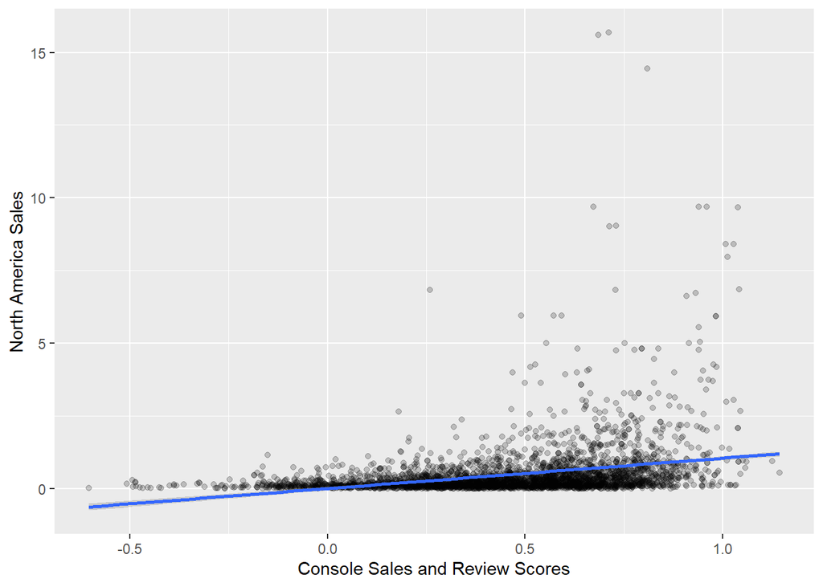

```r
predictions <- train_model %>% predict(test)

ggplot(data = test, aes(x=predictions, y = NA_Sales)) + geom_point(alpha=1/5) + scale_x_continuous(name = "Console Sales and Review Scores") + scale_y_continuous(name = "North America Sales") + geom_smooth(method = "lm")
```

Model with ESRB ratings included.

```r
#User Reviews Model
UserModelNA <- lm(UserBasedDataNA, formula=NA_Sales~Rating)
summary(UserModelNA)
```

```
##
## Call:
## lm(formula = NA_Sales ~ Rating, data = UserBasedDataNA)
##
## Residuals:
##    Min     1Q Median     3Q    Max
## -0.500 -0.320 -0.210  0.009 40.888
##
## Coefficients:
##             Estimate Std. Error t value Pr(>|t|)
## (Intercept)   0.0370     0.1138   0.325 0.745111
## RatingAO      1.2230     0.9590   1.275 0.202238
## RatingE       0.4347     0.1157   3.758 0.000172 ***
## RatingE10+    0.2726     0.1179   2.311 0.020864 *
## RatingK-A     0.2230     0.9590   0.233 0.816125
## RatingM       0.4635     0.1165   3.978 7.02e-05 ***
## RatingRP     -0.0370     0.6829  -0.054 0.956790
## RatingT       0.2545     0.1154   2.204 0.027536 *
## ---
## Signif. codes:  0 '***' 0.001 '**' 0.01 '*' 0.05 '.' 0.1 ' ' 1
##
## Residual standard error: 0.9522 on 7009 degrees of freedom
## Multiple R-squared:  0.01111,    Adjusted R-squared:  0.01012
## F-statistic: 11.24 on 7 and 7009 DF,  p-value: 3.056e-14
```

```r
#Critic Reviews Model
CriticModelNA <- lm(CriticBasedDataNA, formula=NA_Sales~Rating)
summary(CriticModelNA)
```

```
##
## Call:
## lm(formula = NA_Sales ~ Rating, data = CriticBasedDataNA)
##
## Residuals:
##    Min     1Q Median     3Q    Max
## -0.500 -0.320 -0.210  0.009 40.888
##
## Coefficients:
##             Estimate Std. Error t value Pr(>|t|)
## (Intercept)   0.0370     0.1138   0.325 0.745111
## RatingAO      1.2230     0.9590   1.275 0.202238
## RatingE       0.4347     0.1157   3.758 0.000172 ***
## RatingE10+    0.2726     0.1179   2.311 0.020864 *
## RatingK-A     0.2230     0.9590   0.233 0.816125
## RatingM       0.4635     0.1165   3.978 7.02e-05 ***
## RatingRP     -0.0370     0.6829  -0.054 0.956790
## RatingT       0.2545     0.1154   2.204 0.027536 *
## ---
## Signif. codes:  0 '***' 0.001 '**' 0.01 '*' 0.05 '.' 0.1 ' ' 1
##
## Residual standard error: 0.9522 on 7009 degrees of freedom
## Multiple R-squared:  0.01111,    Adjusted R-squared:  0.01012
## F-statistic: 11.24 on 7 and 7009 DF,  p-value: 3.056e-14
```

#### Europe

```r
#Randomly pick 75% of the data to split.
index <- DataEU$EU_Sales %>% createDataPartition(p = 0.75, list = FALSE)

train <-DataEU[index, ]
test <-DataEU[-index,]

train_model <- lm(train, formula=EU_Sales~EU_Console_Sales+User_Score+Critic_Score)
summary(train_model)
```

```
##
## Call:
## lm(formula = EU_Sales ~ EU_Console_Sales + User_Score + Critic_Score,
##     data = train)
##
## Residuals:
##     Min      1Q  Median      3Q     Max
## -0.7200 -0.2483 -0.1095  0.0663 28.6464
##
## Coefficients:
##                    Estimate Std. Error t value Pr(>|t|)
## (Intercept)      -0.2783810  0.0367194  -7.581 3.71e-14 ***
## EU_Console_Sales  0.0042273  0.0003776  11.196  < 2e-16 ***
## User_Score       -0.0044314  0.0005127  -8.644  < 2e-16 ***
## Critic_Score      0.0133135  0.0005337  24.944  < 2e-16 ***
## ---
## Signif. codes:  0 '***' 0.001 '**' 0.01 '*' 0.05 '.' 0.1 ' ' 1
##
## Residual standard error: 0.6382 on 10427 degrees of freedom
##   (1223 observations deleted due to missingness)
## Multiple R-squared:  0.06486,    Adjusted R-squared:  0.06459
## F-statistic: 241.1 on 3 and 10427 DF,  p-value: < 2.2e-16
```

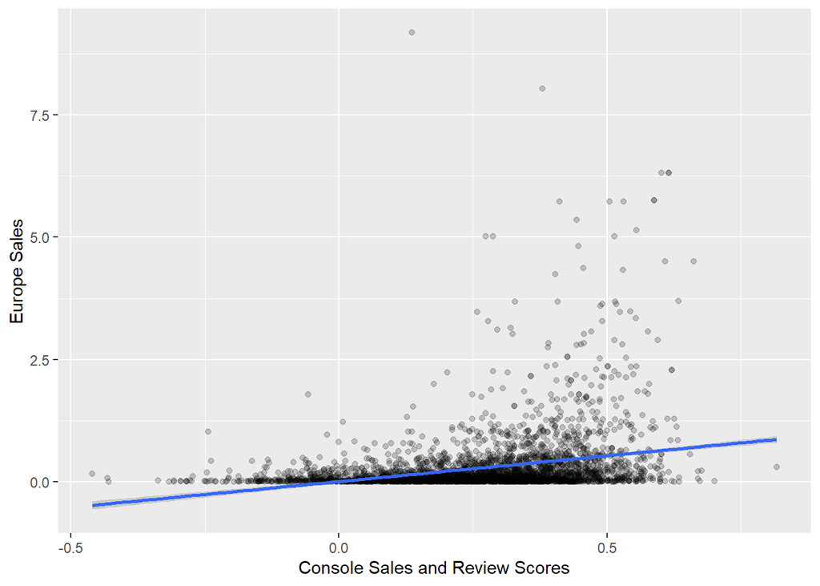

```r
predictions <- train_model %>% predict(test)

ggplot(data = test, aes(x=predictions, y = EU_Sales)) + geom_point(alpha=1/5) + scale_x_continuous(name = "Console Sales and Review Scores") + scale_y_continuous(name = "Europe Sales") + geom_smooth(method = "lm")
```

Model with ESRB ratings included.

```r
#User Reviews Model
UserModelEU <- lm(UserBasedDataEU, formula=EU_Sales~Rating)
summary(UserModelEU)
```

```
##
## Call:
## lm(formula = EU_Sales ~ Rating, data = UserBasedDataEU)
##
## Residuals:
##     Min      1Q  Median      3Q     Max
## -0.3229 -0.2312 -0.1461 -0.0129 28.6788
##
## Coefficients:
##             Estimate Std. Error t value Pr(>|t|)
## (Intercept)  0.07900    0.08080   0.978  0.32827
## RatingAO     0.53100    0.68087   0.780  0.43548
## RatingE      0.20224    0.08213   2.463  0.01382 *
## RatingE10+   0.09083    0.08374   1.085  0.27810
## RatingK-A    0.08100    0.68087   0.119  0.90531
## RatingM      0.24385    0.08272   2.948  0.00321 **
## RatingRP    -0.04400    0.48482  -0.091  0.92769
## RatingT      0.08707    0.08196   1.062  0.28814
## ---
## Signif. codes:  0 '***' 0.001 '**' 0.01 '*' 0.05 '.' 0.1 ' ' 1
##
## Residual standard error: 0.6761 on 7009 degrees of freedom
## Multiple R-squared:  0.01026,    Adjusted R-squared:  0.009272
## F-statistic: 10.38 on 7 and 7009 DF,  p-value: 5.031e-13
```

```r
#Critic Reviews Model
CriticModelEU <- lm(CriticBasedDataEU, formula=EU_Sales~Rating)
summary(CriticModelEU)
```

```
##
## Call:
## lm(formula = EU_Sales ~ Rating, data = CriticBasedDataEU)
##
## Residuals:
##     Min      1Q  Median      3Q     Max
## -0.3229 -0.2312 -0.1461 -0.0129 28.6788
##
## Coefficients:
##             Estimate Std. Error t value Pr(>|t|)
## (Intercept)  0.07900    0.08080   0.978  0.32827
## RatingAO     0.53100    0.68087   0.780  0.43548
## RatingE      0.20224    0.08213   2.463  0.01382 *
## RatingE10+   0.09083    0.08374   1.085  0.27810
## RatingK-A    0.08100    0.68087   0.119  0.90531
## RatingM      0.24385    0.08272   2.948  0.00321 **
## RatingRP    -0.04400    0.48482  -0.091  0.92769
## RatingT      0.08707    0.08196   1.062  0.28814
## ---
## Signif. codes:  0 '***' 0.001 '**' 0.01 '*' 0.05 '.' 0.1 ' ' 1
##
## Residual standard error: 0.6761 on 7009 degrees of freedom
## Multiple R-squared:  0.01026,    Adjusted R-squared:  0.009272
## F-statistic: 10.38 on 7 and 7009 DF,  p-value: 5.031e-13
```

#### Japan

```r
#Randomly pick 75% of the data to split.
index <- DataJP$JP_Sales %>% createDataPartition(p = 0.75, list = FALSE)

train <-DataJP[index, ]
test <-DataJP[-index,]

train_model <- lm(train, formula=JP_Sales~JP_Console_Sales+User_Score+Critic_Score)
summary(train_model)
```

```
##
## Call:
## lm(formula = JP_Sales ~ JP_Console_Sales + User_Score + Critic_Score,
##     data = train)
##
## Residuals:
##     Min      1Q  Median      3Q     Max
## -0.1309 -0.0558 -0.0300  0.0007  6.3669
##
## Coefficients:
##                    Estimate Std. Error t value Pr(>|t|)
## (Intercept)      -0.1240087  0.0110336 -11.239  < 2e-16 ***
## JP_Console_Sales  0.0024509  0.0001994  12.292  < 2e-16 ***
## User_Score        0.0006880  0.0001624   4.237 2.29e-05 ***
## Critic_Score      0.0016218  0.0001684   9.628  < 2e-16 ***
## ---
## Signif. codes:  0 '***' 0.001 '**' 0.01 '*' 0.05 '.' 0.1 ' ' 1
##
## Residual standard error: 0.2012 on 10413 degrees of freedom
##   (1236 observations deleted due to missingness)
## Multiple R-squared:  0.03107,    Adjusted R-squared:  0.03079
## F-statistic: 111.3 on 3 and 10413 DF,  p-value: < 2.2e-16
```

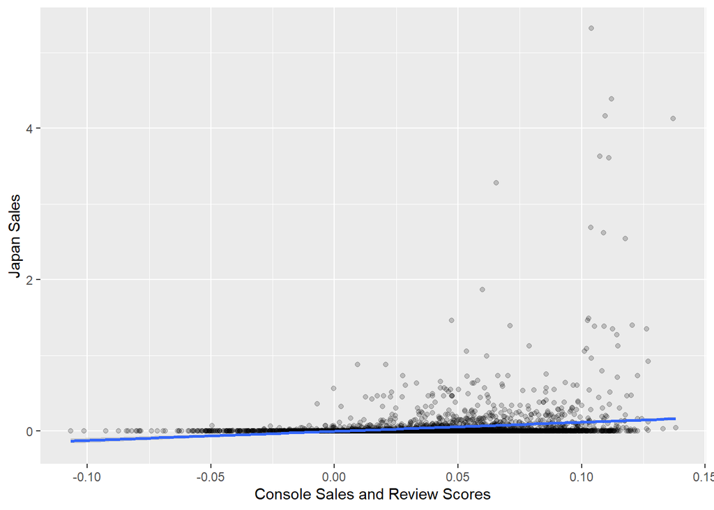

```r
predictions <- train_model %>% predict(test)

ggplot(data = test, aes(x=predictions, y = JP_Sales)) + geom_point(alpha=1/5) + scale_x_continuous(name = "Console Sales and Review Scores") + scale_y_continuous(name = "Japan Sales") + geom_smooth(method = "lm")
```

Model with ESRB ratings included.

```r
#User Reviews Model
UserModelJP <- lm(UserBasedDataJP, formula=JP_Sales~Rating)
summary(UserModelJP)
```

```
##
## Call:
## lm(formula = JP_Sales ~ Rating, data = UserBasedDataJP)
##
## Residuals:
##     Min      1Q  Median      3Q     Max
## -0.0901 -0.0601 -0.0501 -0.0401  6.4099
##
## Coefficients:
##              Estimate Std. Error t value Pr(>|t|)
## (Intercept)  0.034714   0.033842   1.026    0.305
## RatingAO    -0.034714   0.285156  -0.122    0.903
## RatingE      0.055338   0.034397   1.609    0.108
## RatingE10+   0.006311   0.035072   0.180    0.857
## RatingK-A    1.425286   0.285156   4.998 5.93e-07 ***
## RatingM      0.008425   0.034644   0.243    0.808
## RatingRP    -0.034714   0.203051  -0.171    0.864
## RatingT      0.025352   0.034328   0.739    0.460
## ---
## Signif. codes:  0 '***' 0.001 '**' 0.01 '*' 0.05 '.' 0.1 ' ' 1
##
## Residual standard error: 0.2831 on 7009 degrees of freedom
## Multiple R-squared:  0.00816,    Adjusted R-squared:  0.007169
## F-statistic: 8.237 on 7 and 7009 DF,  p-value: 4.874e-10
```

```r
#Critic Reviews Model
CriticModelJP <- lm(CriticBasedDataJP, formula=JP_Sales~Rating)
summary(CriticModelJP)
```

```
##
## Call:
## lm(formula = JP_Sales ~ Rating, data = CriticBasedDataJP)
##
## Residuals:
##     Min      1Q  Median      3Q     Max
## -0.0901 -0.0601 -0.0501 -0.0401  6.4099
##
## Coefficients:
##              Estimate Std. Error t value Pr(>|t|)
## (Intercept)  0.034714   0.033842   1.026    0.305
## RatingAO    -0.034714   0.285156  -0.122    0.903
## RatingE      0.055338   0.034397   1.609    0.108
## RatingE10+   0.006311   0.035072   0.180    0.857
## RatingK-A    1.425286   0.285156   4.998 5.93e-07 ***
## RatingM      0.008425   0.034644   0.243    0.808
## RatingRP    -0.034714   0.203051  -0.171    0.864
## RatingT      0.025352   0.034328   0.739    0.460
## ---
## Signif. codes:  0 '***' 0.001 '**' 0.01 '*' 0.05 '.' 0.1 ' ' 1
##
## Residual standard error: 0.2831 on 7009 degrees of freedom
## Multiple R-squared:  0.00816,    Adjusted R-squared:  0.007169
## F-statistic: 8.237 on 7 and 7009 DF,  p-value: 4.874e-10
```

#### Global

```r
#Randomly pick 75% of the data to split.
index <- DataGlobal$Global_Sales %>% createDataPartition(p = 0.75, list = FALSE)

train <-DataGlobal[index, ]
test <-DataGlobal[-index,]

train_model <- lm(train, formula=Global_Sales~Global_Console_Sales+User_Score+Critic_Score)
summary(train_model)
```

```
##
## Call:
## lm(formula = Global_Sales ~ Global_Console_Sales + User_Score +
##     Critic_Score, data = train)
##
## Residuals:
##    Min     1Q Median     3Q    Max
## -2.093 -0.700 -0.305  0.203 81.463
##
## Coefficients:
##                        Estimate Std. Error t value Pr(>|t|)
## (Intercept)          -1.0397218  0.1008584 -10.309  < 2e-16 ***
## Global_Console_Sales  0.0048125  0.0003887  12.380  < 2e-16 ***
## User_Score           -0.0101634  0.0014080  -7.218 5.63e-13 ***
## Critic_Score          0.0403467  0.0014735  27.382  < 2e-16 ***
## ---
## Signif. codes:  0 '***' 0.001 '**' 0.01 '*' 0.05 '.' 0.1 ' ' 1
##
## Residual standard error: 1.763 on 10406 degrees of freedom
##   (1244 observations deleted due to missingness)
## Multiple R-squared:  0.07985,    Adjusted R-squared:  0.07958
## F-statistic:   301 on 3 and 10406 DF,  p-value: < 2.2e-16
```

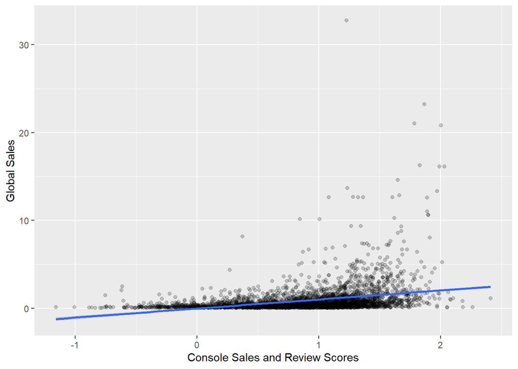

```r
predictions <- train_model %>% predict(test)

ggplot(data = test, aes(x=predictions, y = Global_Sales)) + geom_point(alpha=1/5) + scale_x_continuous(name = "Console Sales and Review Scores") + scale_y_continuous(name = "Global Sales") + geom_smooth(method = "lm")
```

Model with ESRB ratings included.

```r
#User Reviews Model
UserModelGlobal <- lm(UserBasedDataGlobal, formula=Global_Sales~Rating)
summary(UserModelGlobal)
```

```
##
## Call:
## lm(formula = Global_Sales ~ Rating, data = UserBasedDataGlobal)
##
## Residuals:
##    Min     1Q Median     3Q    Max
## -0.975 -0.635 -0.415  0.003 81.595
##
## Coefficients:
##             Estimate Std. Error t value Pr(>|t|)
## (Intercept)   0.1667     0.2308   0.722 0.470134
## RatingAO      1.7833     1.9448   0.917 0.359211
## RatingE       0.7680     0.2346   3.274 0.001067 **
## RatingE10+    0.4185     0.2392   1.749 0.080264 .
## RatingK-A     1.7533     1.9448   0.902 0.367351
## RatingM       0.8182     0.2363   3.463 0.000538 ***
## RatingRP     -0.1317     1.3849  -0.095 0.924230
## RatingT       0.4103     0.2341   1.753 0.079702 .
## ---
## Signif. codes:  0 '***' 0.001 '**' 0.01 '*' 0.05 '.' 0.1 ' ' 1
##
## Residual standard error: 1.931 on 7009 degrees of freedom
## Multiple R-squared:  0.01047,    Adjusted R-squared:  0.009479
## F-statistic: 10.59 on 7 and 7009 DF,  p-value: 2.542e-13
```

```r
#Critic Reviews Model
CriticModelGlobal <- lm(CriticBasedDataGlobal, formula=Global_Sales~Rating)
summary(CriticModelGlobal)
```

```
##
## Call:
## lm(formula = Global_Sales ~ Rating, data = CriticBasedDataGlobal)
##
## Residuals:
##    Min     1Q Median     3Q    Max
## -0.975 -0.635 -0.415  0.003 81.595
##
## Coefficients:
##             Estimate Std. Error t value Pr(>|t|)
## (Intercept)   0.1667     0.2308   0.722 0.470134
## RatingAO      1.7833     1.9448   0.917 0.359211
## RatingE       0.7680     0.2346   3.274 0.001067 **
## RatingE10+    0.4185     0.2392   1.749 0.080264 .
## RatingK-A     1.7533     1.9448   0.902 0.367351
## RatingM       0.8182     0.2363   3.463 0.000538 ***
## RatingRP     -0.1317     1.3849  -0.095 0.924230
## RatingT       0.4103     0.2341   1.753 0.079702 .
## ---
## Signif. codes:  0 '***' 0.001 '**' 0.01 '*' 0.05 '.' 0.1 ' ' 1
##
## Residual standard error: 1.931 on 7009 degrees of freedom
## Multiple R-squared:  0.01047,    Adjusted R-squared:  0.009479
## F-statistic: 10.59 on 7 and 7009 DF,  p-value: 2.542e-13
```